# R Notebook

Kevin Kirotich

You are a Data analyst at Carrefour Kenya and are currently undertaking a project that will inform the marketing department on the most relevant marketing strategies that will result in the highest no. of sales (total price including tax). Your project has been divided into four parts where you’ll explore a recent marketing dataset by performing various unsupervised learning techniques and later providing recommendations based on your insights.

```r
install.packages("data.table")
install.packages("tidyverse")
install.packages("lubridate")
install.packages('cutr')
install.packages('modeest')
install.packages('moments')
install.packages('janitor')
install.packages('ggcorrplot')
install.packages('caret')
install.packages('arules')
install.packages("anomalize")
install.packages('tibbletime')
install.packages('timetk')
install.packages("arulesViz")
install.packages("dplyr")
install.packages("tibble")
install.packages("tibbletime")
install.packages('dummies')
install.packages('devtools')
```

|  | binary | source | needs_compilation |
| --- | --- | --- | --- |
| devtools | 2.4.2 | 2.4.3 | FALSE |

```
installing the source package ‘devtools’
```

[output not shown]

[output cut: 16 more lines]

[output not shown]

```r
install.packages("grid")
install.packages("reshape2")
install.packages("plyr")
install.packages("scales")
install.packages("ggplot2")
install.packages("corrplot")
```

```r
library(ggplot2)
library(reshape2)
library(plyr)
library(grid)
library(scales)
library(corrplot)
library(devtools)
```

```r
library("data.table")
library("tidyverse")
library('lubridate')
library("modeest")
library("moments")
library("janitor")
library(ggcorrplot)
library('caret')
library('arules')
library('anomalize')
library('tibbletime')
library('timetk')
library('arulesViz')
require('dplyr')
library('dummies')
library('devtools')
library(dplyr)
```

```r
library(readr)

#Reading data
Sales <- read.csv('http://bit.ly/CarreFourDataset')
head(Sales)
```

|  | Invoice.ID | Branch | Customer.type | Gender | Product.line | Unit.price | Quantity | Tax | Date | Time | Payment | cogs | gross.margin.percentage | gross.income | Rating | Total |
| --- | --- | --- | --- | --- | --- | --- | --- | --- | --- | --- | --- | --- | --- | --- | --- | --- |
| 1 | 750-67-8428 | A | Member | Female | Health and beauty | 74.69 | 7 | 26.1415 | 1/5/2019 | 13:08 | Ewallet | 522.83 | 4.761905 | 26.1415 | 9.1 | 548.9715 |
| 2 | 226-31-3081 | C | Normal | Female | Electronic accessories | 15.28 | 5 | 3.8200 | 3/8/2019 | 10:29 | Cash | 76.40 | 4.761905 | 3.8200 | 9.6 | 80.2200 |
| 3 | 631-41-3108 | A | Normal | Male | Home and lifestyle | 46.33 | 7 | 16.2155 | 3/3/2019 | 13:23 | Credit card | 324.31 | 4.761905 | 16.2155 | 7.4 | 340.5255 |
| 4 | 123-19-1176 | A | Member | Male | Health and beauty | 58.22 | 8 | 23.2880 | 1/27/2019 | 20:33 | Ewallet | 465.76 | 4.761905 | 23.2880 | 8.4 | 489.0480 |
| 5 | 373-73-7910 | A | Normal | Male | Sports and travel | 86.31 | 7 | 30.2085 | 2/8/2019 | 10:37 | Ewallet | 604.17 | 4.761905 | 30.2085 | 5.3 | 634.3785 |
| 6 | 699-14-3026 | C | Normal | Male | Electronic accessories | 85.39 | 7 | 29.8865 | 3/25/2019 | 18:30 | Ewallet | 597.73 | 4.761905 | 29.8865 | 4.1 | 627.6165 |

```r
NA
```

```r
#Checking the dimensions of the dataset

dim(Sales)
```

```
[1] 1000   16
```

```r
#Check the summary of  numerical columns

summary(Sales)
```

```
  Invoice.ID           Branch          Customer.type
 Length:1000        Length:1000        Length:1000
 Class :character   Class :character   Class :character
 Mode  :character   Mode  :character   Mode  :character



    Gender          Product.line         Unit.price       Quantity
 Length:1000        Length:1000        Min.   :10.08   Min.   : 1.00
 Class :character   Class :character   1st Qu.:32.88   1st Qu.: 3.00
 Mode  :character   Mode  :character   Median :55.23   Median : 5.00
                                       Mean   :55.67   Mean   : 5.51
                                       3rd Qu.:77.94   3rd Qu.: 8.00
                                       Max.   :99.96   Max.   :10.00
      Tax              Date               Time
 Min.   : 0.5085   Length:1000        Length:1000
 1st Qu.: 5.9249   Class :character   Class :character
 Median :12.0880   Mode  :character   Mode  :character
 Mean   :15.3794
 3rd Qu.:22.4453
 Max.   :49.6500
   Payment               cogs        gross.margin.percentage
 Length:1000        Min.   : 10.17   Min.   :4.762
 Class :character   1st Qu.:118.50   1st Qu.:4.762
 Mode  :character   Median :241.76   Median :4.762
                    Mean   :307.59   Mean   :4.762
                    3rd Qu.:448.90   3rd Qu.:4.762
                    Max.   :993.00   Max.   :4.762
  gross.income         Rating           Total
 Min.   : 0.5085   Min.   : 4.000   Min.   :  10.68
 1st Qu.: 5.9249   1st Qu.: 5.500   1st Qu.: 124.42
 Median :12.0880   Median : 7.000   Median : 253.85
 Mean   :15.3794   Mean   : 6.973   Mean   : 322.97
 3rd Qu.:22.4453   3rd Qu.: 8.500   3rd Qu.: 471.35
 Max.   :49.6500   Max.   :10.000   Max.   :1042.65
```

Data Cleaning

```r
#Convert column names to lowercase
names(Sales)<- tolower(names(Sales))
head(Sales)
```

|  | invoice.id | branch | customer.type | gender | product.line | unit.price | quantity | tax | date | time | payment | cogs | gross.margin.percentage | gross.income | rating | total |
| --- | --- | --- | --- | --- | --- | --- | --- | --- | --- | --- | --- | --- | --- | --- | --- | --- |
| 1 | 750-67-8428 | A | Member | Female | Health and beauty | 74.69 | 7 | 26.1415 | 1/5/2019 | 13:08 | Ewallet | 522.83 | 4.761905 | 26.1415 | 9.1 | 548.9715 |
| 2 | 226-31-3081 | C | Normal | Female | Electronic accessories | 15.28 | 5 | 3.8200 | 3/8/2019 | 10:29 | Cash | 76.40 | 4.761905 | 3.8200 | 9.6 | 80.2200 |
| 3 | 631-41-3108 | A | Normal | Male | Home and lifestyle | 46.33 | 7 | 16.2155 | 3/3/2019 | 13:23 | Credit card | 324.31 | 4.761905 | 16.2155 | 7.4 | 340.5255 |
| 4 | 123-19-1176 | A | Member | Male | Health and beauty | 58.22 | 8 | 23.2880 | 1/27/2019 | 20:33 | Ewallet | 465.76 | 4.761905 | 23.2880 | 8.4 | 489.0480 |
| 5 | 373-73-7910 | A | Normal | Male | Sports and travel | 86.31 | 7 | 30.2085 | 2/8/2019 | 10:37 | Ewallet | 604.17 | 4.761905 | 30.2085 | 5.3 | 634.3785 |
| 6 | 699-14-3026 | C | Normal | Male | Electronic accessories | 85.39 | 7 | 29.8865 | 3/25/2019 | 18:30 | Ewallet | 597.73 | 4.761905 | 29.8865 | 4.1 | 627.6165 |

```r
#Checking for missing values in the columns of our dataset


colSums(is.na(Sales))
```

```
             invoice.id                  branch           customer.type
                      0                       0                       0
                 gender            product.line              unit.price
                      0                       0                       0
               quantity                     tax                    date
                      0                       0                       0
                   time                 payment                    cogs
                      0                       0                       0
gross.margin.percentage            gross.income                  rating
                      0                       0                       0
                  total
                      0
```

There is no missing data in any column

```r
anyDuplicated(Sales)
```

```
[1] 0
```

There is no duplicated values in our dataset

```r
# obtaining numerical columns
numeric_columns <- unlist(lapply(Sales, is.numeric))
# Store in a dataframe
columns_numeric <- Sales[ , numeric_columns]
head(columns_numeric)
```

|  | unit.price | quantity | tax | cogs | gross.margin.percentage | gross.income | rating | total |
| --- | --- | --- | --- | --- | --- | --- | --- | --- |
| 1 | 74.69 | 7 | 26.1415 | 522.83 | 4.761905 | 26.1415 | 9.1 | 548.9715 |
| 2 | 15.28 | 5 | 3.8200 | 76.40 | 4.761905 | 3.8200 | 9.6 | 80.2200 |
| 3 | 46.33 | 7 | 16.2155 | 324.31 | 4.761905 | 16.2155 | 7.4 | 340.5255 |
| 4 | 58.22 | 8 | 23.2880 | 465.76 | 4.761905 | 23.2880 | 8.4 | 489.0480 |
| 5 | 86.31 | 7 | 30.2085 | 604.17 | 4.761905 | 30.2085 | 5.3 | 634.3785 |
| 6 | 85.39 | 7 | 29.8865 | 597.73 | 4.761905 | 29.8865 | 4.1 | 627.6165 |

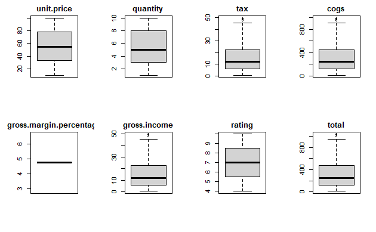

```r
# We will use a for loop to iterate through our numerical values
par ( mfrow= c (  2, 4 ))
for (i in 1 : length (columns_numeric)) {
boxplot (columns_numeric[,i], main= names (columns_numeric[i]), type= "l" , height = 200, width = 110)}
```

There are outliers in tax, gross.income, cogs, and total.  
We wont remove outliers for now because it might cause inaccuracy in our data some outliers like expected like in gross income

```r
lengths(lapply(Sales, unique))
```

```
             invoice.id                  branch           customer.type
                   1000                       3                       2
                 gender            product.line              unit.price
                      2                       6                     943
               quantity                     tax                    date
                     10                     990                      89
                   time                 payment                    cogs
                    506                       3                     990
gross.margin.percentage            gross.income                  rating
                      1                     990                      61
                  total
                    990
```

Univariate analysis Measure of Central Tendancy

```r
#Create a dataframe to store our numerical variables
library(moments)
stats <- data.frame(
  Mean = apply(columns_numeric, 2, mean),
  Median = apply(columns_numeric, 2, median),
  Min = apply(columns_numeric, 2, min),
  Max = apply(columns_numeric, 2, max),
  Variance= apply(columns_numeric, 2, var),
  Std = apply(columns_numeric, 2, sd),
  Skewness = apply(columns_numeric, 2, skewness),
  Kurtosis = apply(columns_numeric, 2, kurtosis))

# round off the values to 2 decimal places and display the data1frame
stats <- round(stats, 2)
stats
```

|  | Mean | Median | Min | Max | Variance | Std | Skewness | Kurtosis |
| --- | --- | --- | --- | --- | --- | --- | --- | --- |
| unit.price | 55.67 | 55.23 | 10.08 | 99.96 | 701.97 | 26.49 | 0.01 | 1.78 |
| quantity | 5.51 | 5.00 | 1.00 | 10.00 | 8.55 | 2.92 | 0.01 | 1.78 |
| tax | 15.38 | 12.09 | 0.51 | 49.65 | 137.10 | 11.71 | 0.89 | 2.91 |
| cogs | 307.59 | 241.76 | 10.17 | 993.00 | 54838.64 | 234.18 | 0.89 | 2.91 |
| gross.margin.percentage | 4.76 | 4.76 | 4.76 | 4.76 | 0.00 | 0.00 | NaN | NaN |
| gross.income | 15.38 | 12.09 | 0.51 | 49.65 | 137.10 | 11.71 | 0.89 | 2.91 |
| rating | 6.97 | 7.00 | 4.00 | 10.00 | 2.95 | 1.72 | 0.01 | 1.85 |
| total | 322.97 | 253.85 | 10.68 | 1042.65 | 60459.60 | 245.89 | 0.89 | 2.91 |

Plots

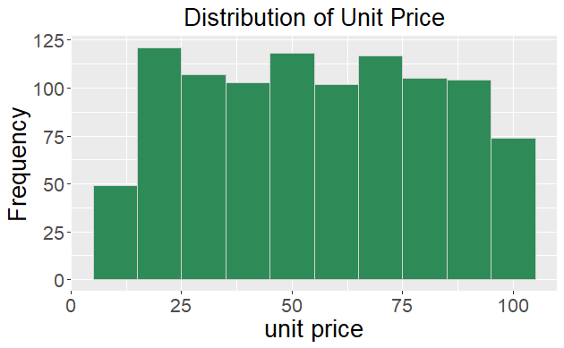

```r
# We will use ggplot to display our plots
library(dplyr)
library(ggplot2)
options(repr.plot.width = 8, repr.plot.height = 6)
p = Sales %>% ggplot(aes(x = unit.price ))

p + geom_histogram(color="lightgray", fill="seagreen", binwidth = 10) +
    labs(title = "Distribution of Unit Price", x = "unit price", y = "Frequency") +
    theme(axis.title = element_text(size = 20),
          axis.text = element_text(size=16),
          plot.title = element_text(hjust = 0.5, size = 20))
```

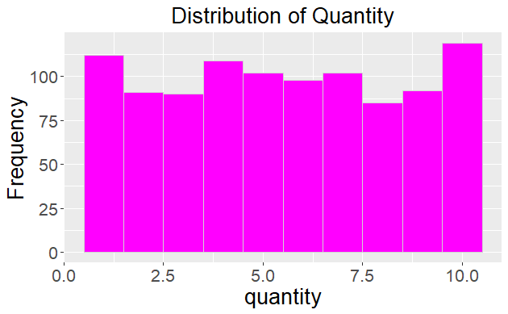

```r
# plot a histogram to visualize the distribution of values in 'quantity' column

options(repr.plot.width = 8, repr.plot.height = 6)
p = Sales %>% ggplot(aes(x = quantity ))

p + geom_histogram(color="lightgray", fill="magenta", binwidth = 1) +
    labs(title = "Distribution of Quantity", x = "quantity", y = "Frequency") +
    theme(axis.title = element_text(size = 20),
          axis.text = element_text(size=16),
          plot.title = element_text(hjust = 0.5, size = 20))
```

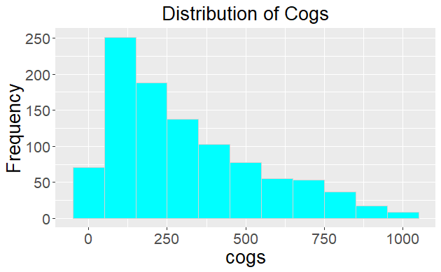

```r
# plot a histogram to visualize the distribution of values in 'cogs' column

options(repr.plot.width = 8, repr.plot.height = 6)
p = Sales %>% ggplot(aes(x = cogs ))

p + geom_histogram(color="lightgray", fill="cyan", binwidth = 100) +
    labs(title = "Distribution of Cogs", x = "cogs", y = "Frequency") +
      theme(axis.title = element_text(size = 20),
          axis.text = element_text(size=16),
          plot.title = element_text(hjust = 0.5, size = 20))
```

Bivariate Analysis

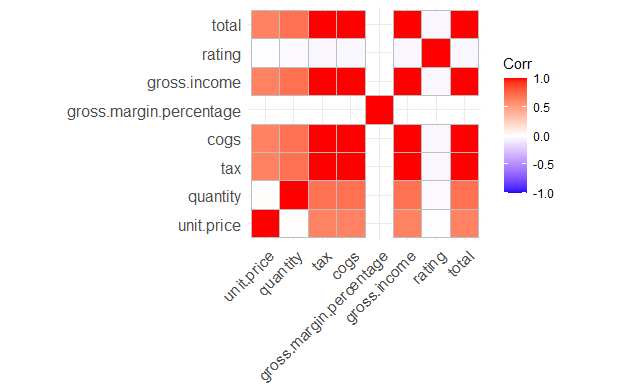

```r
#correlation
library(ggcorrplot)
ggcorrplot(cor(columns_numeric))
```

PCA

```r
df<- columns_numeric[,c(1,2,3,4,6,7,8)]
head(df)
```

|  | unit.price | quantity | tax | cogs | gross.income | rating | total |
| --- | --- | --- | --- | --- | --- | --- | --- |
| 1 | 74.69 | 7 | 26.1415 | 522.83 | 26.1415 | 9.1 | 548.9715 |
| 2 | 15.28 | 5 | 3.8200 | 76.40 | 3.8200 | 9.6 | 80.2200 |
| 3 | 46.33 | 7 | 16.2155 | 324.31 | 16.2155 | 7.4 | 340.5255 |
| 4 | 58.22 | 8 | 23.2880 | 465.76 | 23.2880 | 8.4 | 489.0480 |
| 5 | 86.31 | 7 | 30.2085 | 604.17 | 30.2085 | 5.3 | 634.3785 |
| 6 | 85.39 | 7 | 29.8865 | 597.73 | 29.8865 | 4.1 | 627.6165 |

```r
NA
```

```r
#we use prcomp method to perform PCA
Sales.pca <- prcomp(df, center = TRUE, scale. = TRUE)
summary(Sales.pca)
```

```
Importance of components:
                          PC1    PC2    PC3     PC4       PC5       PC6
Standard deviation     2.2185 1.0002 0.9939 0.30001 2.981e-16 1.493e-16
Proportion of Variance 0.7031 0.1429 0.1411 0.01286 0.000e+00 0.000e+00
Cumulative Proportion  0.7031 0.8460 0.9871 1.00000 1.000e+00 1.000e+00
                             PC7
Standard deviation     9.831e-17
Proportion of Variance 0.000e+00
Cumulative Proportion  1.000e+00
```

We see that PC1 accounts for 70% of the total variance PC2 accounts for 14% of the total variance

```r
#Check nature of our data
str(Sales.pca)
```

```
List of 5
 $ sdev    : num [1:7] 2.22 1.00 9.94e-01 3.00e-01 2.98e-16 ...
 $ rotation: num [1:7, 1:7] -0.292 -0.325 -0.45 -0.45 -0.45 ...
  ..- attr(*, "dimnames")=List of 2
  .. ..$ : chr [1:7] "unit.price" "quantity" "tax" "cogs" ...
  .. ..$ : chr [1:7] "PC1" "PC2" "PC3" "PC4" ...
 $ center  : Named num [1:7] 55.67 5.51 15.38 307.59 15.38 ...
  ..- attr(*, "names")= chr [1:7] "unit.price" "quantity" "tax" "cogs" ...
 $ scale   : Named num [1:7] 26.49 2.92 11.71 234.18 11.71 ...
  ..- attr(*, "names")= chr [1:7] "unit.price" "quantity" "tax" "cogs" ...
 $ x       : num [1:1000, 1:7] -2.005 2.306 -0.186 -1.504 -2.8 ...
  ..- attr(*, "dimnames")=List of 2
  .. ..$ : NULL
  .. ..$ : chr [1:7] "PC1" "PC2" "PC3" "PC4" ...
 - attr(*, "class")= chr "prcomp"
```

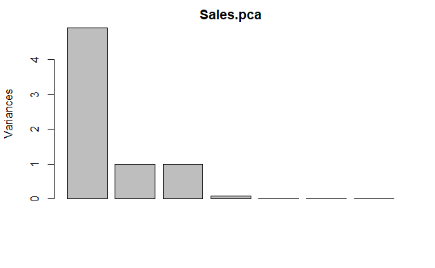

```r
library(biplotbootGUI)
library(BiplotGUI)
library(BiplotML)
plot(Sales.pca)
```

[figure not shown]

```r
biplot(Sales.pca)
```

Wrapper method

```r
# importing required libraries
install.packages("clustvarsel")
library(clustvarsel)
install.packages("mclust")
```

```
Error in install.packages : Updating loaded packages
```

```r
library(mclust)
```

```r
# Sequential forward greedy search (default)
library(clustvarsel)
clustvarsel(columns_numeric)
```

[output not shown]

Feature Selection This section requires you to perform feature selection through the use of the unsupervised learning methods and perform your analysis and provide insights on the features that contribute the most information to the dataset.

```r
library(caret)
```

[output not shown]

[output not shown]

```r
correlationMatrix <- cor(columns_numeric)
highlyCorrelated <- findCorrelation(correlationMatrix, cutoff=0.75)

highlyCorrelated
```

[output not shown]

```r
names(columns_numeric[,highlyCorrelated])
```

```
[1] "cogs"  "total" "tax"
```

[output not shown]

[output cut: 990 more lines]

```r
sales2 <- subset(Sales, select = -c(cogs,  total, tax))

library(corrplot)
par(mfrow = c(1, 2))
corrplot(correlationMatrix, order = "hclust")
```

```
Error in hclust(as.dist(1 - corr), method = hclust.method) :
  NA/NaN/Inf in foreign function call (arg 10)
```

```r
 class(sales2)
```

```
[1] "data.frame"
```

```r
corrplot(correlationMatrix, order = "hclust")
```

```
Error in hclust(as.dist(1 - corr), method = hclust.method) :
  NA/NaN/Inf in foreign function call (arg 10)
```